# Wrangling Project

```r
library(dplyr)
```

```r
library(ggplot2)
library(jsonlite)
library(knitr)
library(lubridate)
library(readr)
library(scales)
library(stringi)
library(stringr)
library(tibble)
library(tidyr)
```

## Data Gathering

```r
archive <- read.csv("twitter-archive-enhanced.csv", stringsAsFactors = FALSE)
```

```r
url <- "https://d17h27t6h515a5.cloudfront.net/topher/2017/August/599fd2ad_image-predictions/image-predictions.tsv"

img_predictions <- read.delim(url, sep = "\t", header = TRUE)
```

```r
api_data <- jsonlite::stream_in(file("tweet_json.txt"))
```

```
## opening file input connection.
```

```
##
 Found 500 records...
 Found 1000 records...
 Found 1500 records...
 Found 2000 records...
 Found 2354 records...
 Imported 2354 records. Simplifying...
```

```
## closing file input connection.
```

```r
api_data <- api_data %>%
  select(id, retweet_count, favorite_count)
```

## Assessing

#### Archive Data

```r
head(archive)
```

|  | tweet_id | in_reply_to_status_id | in_reply_to_user_id | timestamp | source | text | retweeted_status_id | retweeted_status_user_id | retweeted_status_timestamp | expanded_urls | rating_numerator | rating_denominator | name | doggo | floofer | pupper | puppo |
| --- | --- | --- | --- | --- | --- | --- | --- | --- | --- | --- | --- | --- | --- | --- | --- | --- | --- |
| 1 | 8.924206e+17 | NA | NA | 2017-08-01 16:23:56 +0000 | Twitter for iPhone | This is Phineas. He's a mystical boy. Only ever appears in the hole of a donut. 13/10 https://t.co/MgUWQ76dJU | NA | NA |  | https://twitter.com/dog_rates/status/892420643555336193/photo/1 | 13 | 10 | Phineas | None | None | None | None |
| 2 | 8.921774e+17 | NA | NA | 2017-08-01 00:17:27 +0000 | Twitter for iPhone | This is Tilly. She's just checking pup on you. Hopes you're doing ok. If not, she's available for pats, snugs, boops, the whole bit. 13/10 https://t.co/0Xxu71qeIV | NA | NA |  | https://twitter.com/dog_rates/status/892177421306343426/photo/1 | 13 | 10 | Tilly | None | None | None | None |
| 3 | 8.918152e+17 | NA | NA | 2017-07-31 00:18:03 +0000 | Twitter for iPhone | This is Archie. He is a rare Norwegian Pouncing Corgo. Lives in the tall grass. You never know when one may strike. 12/10 https://t.co/wUnZnhtVJB | NA | NA |  | https://twitter.com/dog_rates/status/891815181378084864/photo/1 | 12 | 10 | Archie | None | None | None | None |
| 4 | 8.916896e+17 | NA | NA | 2017-07-30 15:58:51 +0000 | Twitter for iPhone | This is Darla. She commenced a snooze mid meal. 13/10 happens to the best of us https://t.co/tD36da7qLQ | NA | NA |  | https://twitter.com/dog_rates/status/891689557279858688/photo/1 | 13 | 10 | Darla | None | None | None | None |
| 5 | 8.913276e+17 | NA | NA | 2017-07-29 16:00:24 +0000 | Twitter for iPhone | This is Franklin. He would like you to stop calling him "cute." He is a very fierce shark and should be respected as such. 12/10 #BarkWeek https://t.co/AtUZn91f7f | NA | NA |  | https://twitter.com/dog_rates/status/891327558926688256/photo/1,https://twitter.com/dog_rates/status/891327558926688256/photo/1 | 12 | 10 | Franklin | None | None | None | None |
| 6 | 8.910880e+17 | NA | NA | 2017-07-29 00:08:17 +0000 | Twitter for iPhone | Here we have a majestic great white breaching off South Africa's coast. Absolutely h*ckin breathtaking. 13/10 (IG: tucker_marlo) #BarkWeek https://t.co/kQ04fDDRmh | NA | NA |  | https://twitter.com/dog_rates/status/891087950875897856/photo/1 | 13 | 10 | None | None | None | None | None |

```r
kable(table(archive$source), col.names = c("Source", "Count"))
```

| Source | Count |
| --- | --- |
| [Twitter Web Client](http://twitter.com) | 33 |
| [Twitter for iPhone](http://twitter.com/download/iphone) | 2221 |
| [Vine - Make a Scene](http://vine.co) | 91 |
| [TweetDeck](https://about.twitter.com/products/tweetdeck) | 11 |

```r
head(archive$text)
```

```
## [1] "This is Phineas. He's a mystical boy. Only ever appears in the hole of a donut. 13/10 https://t.co/MgUWQ76dJU"
## [2] "This is Tilly. She's just checking pup on you. Hopes you're doing ok. If not, she's available for pats, snugs, boops, the whole bit. 13/10 https://t.co/0Xxu71qeIV"
## [3] "This is Archie. He is a rare Norwegian Pouncing Corgo. Lives in the tall grass. You never know when one may strike. 12/10 https://t.co/wUnZnhtVJB"
## [4] "This is Darla. She commenced a snooze mid meal. 13/10 happens to the best of us https://t.co/tD36da7qLQ"
## [5] "This is Franklin. He would like you to stop calling him \"cute.\" He is a very fierce shark and should be respected as such. 12/10 #BarkWeek https://t.co/AtUZn91f7f"
## [6] "Here we have a majestic great white breaching off South Africa's coast. Absolutely h*ckin breathtaking. 13/10 (IG: tucker_marlo) #BarkWeek https://t.co/kQ04fDDRmh"
```

```r
str(archive)
```

```
## 'data.frame':    2356 obs. of  17 variables:
##  $ tweet_id                  : num  8.92e+17 8.92e+17 8.92e+17 8.92e+17 8.91e+17 ...
##  $ in_reply_to_status_id     : num  NA NA NA NA NA NA NA NA NA NA ...
##  $ in_reply_to_user_id       : num  NA NA NA NA NA NA NA NA NA NA ...
##  $ timestamp                 : chr  "2017-08-01 16:23:56 +0000" "2017-08-01 00:17:27 +0000" "2017-07-31 00:18:03 +0000" "2017-07-30 15:58:51 +0000" ...
##  $ source                    : chr  "<a href=\"http://twitter.com/download/iphone\" rel=\"nofollow\">Twitter for iPhone</a>" "<a href=\"http://twitter.com/download/iphone\" rel=\"nofollow\">Twitter for iPhone</a>" "<a href=\"http://twitter.com/download/iphone\" rel=\"nofollow\">Twitter for iPhone…
##  $ text                      : chr  "This is Phineas. He's a mystical boy. Only ever appears in the hole of a donut. 13/10 https://t.co/MgUWQ76dJU" "This is Tilly. She's just checking pup on you. Hopes you're doing ok. If not, she's available for pats, snugs, "| __truncated__ "This is Archie. He …
##  $ retweeted_status_id       : num  NA NA NA NA NA NA NA NA NA NA ...
##  $ retweeted_status_user_id  : num  NA NA NA NA NA NA NA NA NA NA ...
##  $ retweeted_status_timestamp: chr  "" "" "" "" ...
##  $ expanded_urls             : chr  "https://twitter.com/dog_rates/status/892420643555336193/photo/1" "https://twitter.com/dog_rates/status/892177421306343426/photo/1" "https://twitter.com/dog_rates/status/891815181378084864/photo/1" "https://twitter.com/dog_rates/status/891689557279858688/photo/…
##  $ rating_numerator          : int  13 13 12 13 12 13 13 13 13 14 ...
##  $ rating_denominator        : int  10 10 10 10 10 10 10 10 10 10 ...
##  $ name                      : chr  "Phineas" "Tilly" "Archie" "Darla" ...
##  $ doggo                     : chr  "None" "None" "None" "None" ...
##  $ floofer                   : chr  "None" "None" "None" "None" ...
##  $ pupper                    : chr  "None" "None" "None" "None" ...
##  $ puppo                     : chr  "None" "None" "None" "None" ...
```

```r
kable(colSums(!is.na(archive)), col.names = c("Column", "Non-Null Count"))
```

| Column | Non-Null Count |
| --- | --- |
| tweet_id | 2356 |
| in_reply_to_status_id | 78 |
| in_reply_to_user_id | 78 |
| timestamp | 2356 |
| source | 2356 |
| text | 2356 |
| retweeted_status_id | 181 |
| retweeted_status_user_id | 181 |
| retweeted_status_timestamp | 2356 |
| expanded_urls | 2356 |
| rating_numerator | 2356 |
| rating_denominator | 2356 |
| name | 2356 |
| doggo | 2356 |
| floofer | 2356 |
| pupper | 2356 |
| puppo | 2356 |

```r
len <- nrow(table(archive$rating_numerator))

print(table(archive$rating_numerator)[1:(len/2)])
```

```
##
##   0   1   2   3   4   5   6   7   8   9  10  11  12  13  14  15  17  20  24  26
##   2   9   9  19  17  37  32  55 102 158 461 464 558 351  54   2   1   1   1   1
```

```r
print(table(archive$rating_numerator)[(len/2):len])
```

```
##
##   26   27   44   45   50   60   75   80   84   88   99  121  143  144  165  182
##    1    1    1    1    1    1    2    1    1    1    1    1    1    1    1    1
##  204  420  666  960 1776
##    1    2    1    1    1
```

```r
archive %>%
  filter(rating_numerator > 14) %>%
  select(text, rating_numerator, rating_denominator) %>%
  slice_head(n = 10)
```

| text | rating_numerator | rating_denominator |
| --- | --- | --- |
| @roushfenway These are good dogs but 17/10 is an emotional impulse rating. More like 13/10s | 17 | 10 |
| @dhmontgomery We also gave snoop dogg a 420/10 but I think that predated your research | 420 | 10 |
| @s8n You tried very hard to portray this good boy as not so good, but you have ultimately failed. His goodness shines through. 666/10 | 666 | 10 |
| RT @KibaDva: I collected all the good dogs!! 15/10 @dog_rates #GoodDogs https://t.co/6UCGFczlOI | 15 | 10 |
| @markhoppus 182/10 | 182 | 10 |
| @bragg6of8 @Andy_Pace_ we are still looking for the first 15/10 | 15 | 10 |
| @jonnysun @Lin_Manuel ok jomny I know you're excited but 960/00 isn't a valid rating, 13/10 is tho | 960 | 0 |
| RT @dog_rates: This is Logan, the Chow who lived. He solemnly swears he's up to lots of good. H*ckin magical af 9.75/10 https://t.co/yBO5wu… | 75 | 10 |
| The floofs have been released I repeat the floofs have been released. 84/70 https://t.co/NIYC820tmd | 84 | 70 |
| Meet Sam. She smiles 24/7 &amp; secretly aspires to be a reindeer. \nKeep Sam smiling by clicking and sharing this link:\nhttps://t.co/98tB8y7y7t https://t.co/LouL5vdvxx | 24 | 7 |

📝 The 84/70 rating is for a group of dogs. This warrants further analysis…

```r
table(archive$rating_denominator)
```

```
##
##    0    2    7   10   11   15   16   20   40   50   70   80   90  110  120  130
##    1    1    1 2333    3    1    1    2    1    3    1    2    1    1    1    1
##  150  170
##    1    1
```

#### Image Prediction Data

```r
head(img_predictions)
```

|  | tweet_id | jpg_url | img_num | p1 | p1_conf | p1_dog | p2 | p2_conf | p2_dog | p3 | p3_conf | p3_dog |
| --- | --- | --- | --- | --- | --- | --- | --- | --- | --- | --- | --- | --- |
| 1 | 6.660209e+17 | https://pbs.twimg.com/media/CT4udn0WwAA0aMy.jpg | 1 | Welsh_springer_spaniel | 0.465074 | True | collie | 0.1566650 | True | Shetland_sheepdog | 0.0614285 | True |
| 2 | 6.660293e+17 | https://pbs.twimg.com/media/CT42GRgUYAA5iDo.jpg | 1 | redbone | 0.506826 | True | miniature_pinscher | 0.0741917 | True | Rhodesian_ridgeback | 0.0720100 | True |
| 3 | 6.660334e+17 | https://pbs.twimg.com/media/CT4521TWwAEvMyu.jpg | 1 | German_shepherd | 0.596461 | True | malinois | 0.1385840 | True | bloodhound | 0.1161970 | True |
| 4 | 6.660442e+17 | https://pbs.twimg.com/media/CT5Dr8HUEAA-lEu.jpg | 1 | Rhodesian_ridgeback | 0.408143 | True | redbone | 0.3606870 | True | miniature_pinscher | 0.2227520 | True |
| 5 | 6.660492e+17 | https://pbs.twimg.com/media/CT5IQmsXIAAKY4A.jpg | 1 | miniature_pinscher | 0.560311 | True | Rottweiler | 0.2436820 | True | Doberman | 0.1546290 | True |
| 6 | 6.660508e+17 | https://pbs.twimg.com/media/CT5Jof1WUAEuVxN.jpg | 1 | Bernese_mountain_dog | 0.651137 | True | English_springer | 0.2637880 | True | Greater_Swiss_Mountain_dog | 0.0161992 | True |

```r
str(img_predictions)
```

```
## 'data.frame':    2075 obs. of  12 variables:
##  $ tweet_id: num  6.66e+17 6.66e+17 6.66e+17 6.66e+17 6.66e+17 ...
##  $ jpg_url : chr  "https://pbs.twimg.com/media/CT4udn0WwAA0aMy.jpg" "https://pbs.twimg.com/media/CT42GRgUYAA5iDo.jpg" "https://pbs.twimg.com/media/CT4521TWwAEvMyu.jpg" "https://pbs.twimg.com/media/CT5Dr8HUEAA-lEu.jpg" ...
##  $ img_num : int  1 1 1 1 1 1 1 1 1 1 ...
##  $ p1      : chr  "Welsh_springer_spaniel" "redbone" "German_shepherd" "Rhodesian_ridgeback" ...
##  $ p1_conf : num  0.465 0.507 0.596 0.408 0.56 ...
##  $ p1_dog  : chr  "True" "True" "True" "True" ...
##  $ p2      : chr  "collie" "miniature_pinscher" "malinois" "redbone" ...
##  $ p2_conf : num  0.1567 0.0742 0.1386 0.3607 0.2437 ...
##  $ p2_dog  : chr  "True" "True" "True" "True" ...
##  $ p3      : chr  "Shetland_sheepdog" "Rhodesian_ridgeback" "bloodhound" "miniature_pinscher" ...
##  $ p3_conf : num  0.0614 0.072 0.1162 0.2228 0.1546 ...
##  $ p3_dog  : chr  "True" "True" "True" "True" ...
```

#### API Data

```r
head(api_data)
```

|  | id | retweet_count | favorite_count |
| --- | --- | --- | --- |
| 1 | 8.924206e+17 | 8853 | 39467 |
| 2 | 8.921774e+17 | 6514 | 33819 |
| 3 | 8.918152e+17 | 4328 | 25461 |
| 4 | 8.916896e+17 | 8964 | 42908 |
| 5 | 8.913276e+17 | 9774 | 41048 |
| 6 | 8.910880e+17 | 3261 | 20562 |

```r
str(api_data)
```

```
## 'data.frame':    2354 obs. of  3 variables:
##  $ id            : num  8.92e+17 8.92e+17 8.92e+17 8.92e+17 8.91e+17 ...
##  $ retweet_count : int  8853 6514 4328 8964 9774 3261 2158 16716 4429 7711 ...
##  $ favorite_count: int  39467 33819 25461 42908 41048 20562 12041 56848 28226 32467 ...
```

### Tidiness Issues

1. The tweet data spans multiple tables. The **`api_data`** consists of additional data on the tweets in **`archive`**, and the **`img_predictions`** are largely for the images in those tweets. As all three tables pertain to the same crop of tweets, they should be merged into a super table.
2. The “dog stage” data spans multiple columns: `doggo`, `floofer`, `pupper`, and `puppo` are values of the “dog stage” variable.

## Cleaning Data

```r
# Make copies of original pieces of data
archive_clean <- archive
api_data_clean <- api_data
img_predict_clean <- img_predictions
```

### Issue 1: The ‘archive’ table includes retweets.

#### Define: Filter for tweets without `retweeted_` data. And deselect the now useless `retweeted_` columns.

*If a tweet has `retweeted_` data, it’s a retweet.

#### Code

```r
archive_clean <- archive_clean %>%
  filter(is.na(retweeted_status_id))
```

```r
archive_clean <- archive_clean %>%
  select(-retweeted_status_id, -retweeted_status_user_id,
         -retweeted_status_timestamp)
```

#### Test

```r
kable(names(archive_clean), col.names = "Column Names")
```

| Column Names |
| --- |
| tweet_id |
| in_reply_to_status_id |
| in_reply_to_user_id |
| timestamp |
| source |
| text |
| expanded_urls |
| rating_numerator |
| rating_denominator |
| name |
| doggo |
| floofer |
| pupper |
| puppo |

### Issue 2: The ‘archive’ table includes tweets without URLs.

#### Define: Filter for tweets with `expanded_urls`.

#### Code

```r
archive_clean <- archive_clean %>%
  filter(!is.na(expanded_urls))
```

#### Test

```r
kable(colSums(!is.na(archive_clean)), col.names = c("Column", "Non-Null Count"))
```

| Column | Non-Null Count |
| --- | --- |
| tweet_id | 2175 |
| in_reply_to_status_id | 78 |
| in_reply_to_user_id | 78 |
| timestamp | 2175 |
| source | 2175 |
| text | 2175 |
| expanded_urls | 2175 |
| rating_numerator | 2175 |
| rating_denominator | 2175 |
| name | 2175 |
| doggo | 2175 |
| floofer | 2175 |
| pupper | 2175 |
| puppo | 2175 |

### Issue 3: The tweet data spans multiple tables.

#### Define: Join the tables, renaming the key columns as needed.

#### Code

```r
api_data_clean <- api_data_clean %>%
  rename(tweet_id = id)
```

```r
archive_clean <- inner_join(api_data_clean, archive_clean, by = "tweet_id") %>%
  inner_join(img_predict_clean, by = "tweet_id")
```

#### Test

```r
kable(colSums(!is.na(archive_clean)), col.names = c("Column", "Non-Null Count"))
```

| Column | Non-Null Count |
| --- | --- |
| tweet_id | 1994 |
| retweet_count | 1994 |
| favorite_count | 1994 |
| in_reply_to_status_id | 23 |
| in_reply_to_user_id | 23 |
| timestamp | 1994 |
| source | 1994 |
| text | 1994 |
| expanded_urls | 1994 |
| rating_numerator | 1994 |
| rating_denominator | 1994 |
| name | 1994 |
| doggo | 1994 |
| floofer | 1994 |
| pupper | 1994 |
| puppo | 1994 |
| jpg_url | 1994 |
| img_num | 1994 |
| p1 | 1994 |
| p1_conf | 1994 |
| p1_dog | 1994 |
| p2 | 1994 |
| p2_conf | 1994 |
| p2_dog | 1994 |
| p3 | 1994 |
| p3_conf | 1994 |
| p3_dog | 1994 |

### Issue 4: The “dog stage” data spans multiple columns: `doggo`, `floofer`, `pupper`, and `puppo` are values of the “dog stage” variable.

Most of the values are null.

#### Define: Unite the “dog stage” column’s values into a new `dog_stage` column, but only the non-null values.

#### Code

```r
dog_stage_col <- c("doggo", "pupper", "floofer", "puppo")

archive_clean <- archive_clean %>%
  mutate(across(all_of(dog_stage_col), ~ ifelse(. == "None", NA_character_, .)))
```

```r
archive_clean <- archive_clean %>%
  unite(dog_stage, all_of(dog_stage_col), sep = "/", na.rm = TRUE)
```

#### Test

```r
archive_clean %>%
  slice(10:14) %>%
  select(tweet_id, dog_stage)
```

| tweet_id | dog_stage |
| --- | --- |
| 8.902403e+17 | doggo |
| 8.900066e+17 |  |
| 8.898809e+17 |  |
| 8.896654e+17 | puppo |
| 8.896388e+17 |  |

```r
kable(colSums(!is.na(archive_clean)), col.names = c("Column", "Non-Null Count"))
```

| Column | Non-Null Count |
| --- | --- |
| tweet_id | 1994 |
| retweet_count | 1994 |
| favorite_count | 1994 |
| in_reply_to_status_id | 23 |
| in_reply_to_user_id | 23 |
| timestamp | 1994 |
| source | 1994 |
| text | 1994 |
| expanded_urls | 1994 |
| rating_numerator | 1994 |
| rating_denominator | 1994 |
| name | 1994 |
| dog_stage | 1994 |
| jpg_url | 1994 |
| img_num | 1994 |
| p1 | 1994 |
| p1_conf | 1994 |
| p1_dog | 1994 |
| p2 | 1994 |
| p2_conf | 1994 |
| p2_dog | 1994 |
| p3 | 1994 |
| p3_conf | 1994 |
| p3_dog | 1994 |

```r
unique(archive_clean$dog_stage)
```

```
## [1] ""              "doggo"         "puppo"         "pupper"
## [5] "floofer"       "doggo/puppo"   "doggo/floofer" "doggo/pupper"
```

### Issue 4.1: Empty strings are interpreted as non-null.

#### Define: Reassign the empty strings with None.

#### Code

```r
archive_clean$dog_stage <- ifelse(archive_clean$dog_stage == "", NA,
                                  archive_clean$dog_stage)
```

#### Test

```r
archive_clean %>%
  slice(10:14) %>%
  select(tweet_id, dog_stage)
```

| tweet_id | dog_stage |
| --- | --- |
| 8.902403e+17 | doggo |
| 8.900066e+17 | NA |
| 8.898809e+17 | NA |
| 8.896654e+17 | puppo |
| 8.896388e+17 | NA |

```r
sum(!is.na(archive_clean$dog_stage))
```

```
## [1] 306
```

```r
unique(archive_clean$dog_stage)
```

```
## [1] NA              "doggo"         "puppo"         "pupper"
## [5] "floofer"       "doggo/puppo"   "doggo/floofer" "doggo/pupper"
```

### Issue 5: The `source` data includes HTML tags.

#### Define: Replace the messy source data with just the part between the tags.

#### Code

```r
archive_clean$source <- str_replace_all(archive_clean$source,
                                        ".*>(.+)<.*", "\\1")
```

#### Test

```r
unique(archive_clean$source)
```

```
## [1] "Twitter for iPhone" "Twitter Web Client" "TweetDeck"
```

### Issue 6: The `text` data includes URLs referring back to the tweet itself.

#### Define: Remove the tweet URLs.

#### Code

```r
archive_clean$text <- sub(" https://t.co/[a-zA-Z0-9]+", "", archive_clean$text)
```

#### Test

```r
sum(grepl("https://t.co", archive_clean$text))
```

```
## [1] 28
```

```r
head(archive_clean$text[grepl("https://t.co", archive_clean$text)])
```

```
## [1] "Meet Jax. He enjoys ice cream so much he gets nervous around it. 13/10 help Jax enjoy more things by clicking below\n\nhttps://t.co/Zr4hWfAs1H"
## [2] "This is Mingus. He's a wonderful father to his smol pup. Confirmed 13/10, but he needs your help\n\nhttps://t.co/bVi0Yr4Cff"
## [3] "Meet Shadow. In an attempt to reach maximum zooming borkdrive, he tore his ACL. Still 13/10 tho. Help him out below\n\nhttps://t.co/245xJJElsY"
## [4] "This is Sierra. She's one precious pupper. Absolute 12/10. Been in and out of ICU her whole life. Help Sierra below\n\nhttps://t.co/Xp01EU3qyD"
## [5] "This is Cody. He zoomed too aggressively and tore his ACL. Happens to the best of us. Still 13/10\n\nHelp Cody here: https://t.co/42ryYRQ2Q4"
## [6] "Say hello to Cooper. His expression is the same wet or dry. Absolute 12/10 but Coop desperately requests your help\n\nhttps://t.co/ZMTE4Mr69f"
```

✅ These URLs—separated by newlines—point to fundraiser pages: they are part of the tweet.

### Issue 7: Some of the `expanded_urls` values consist of duplicate URLs strung together, separated by commas.

#### Define: Split the multi-URL strings into URL lists. Then, extract the unique, list elements…

#### Code

```r
archive_clean$expanded_urls <- strsplit(archive_clean$expanded_urls, ",")

# Remove duplicates within each list element
archive_clean$expanded_urls <- lapply(
  archive_clean$expanded_urls, function(urls) {
    unique_urls <- unique(urls)
    as.character(unique_urls)
  }
)
```

#### Test

```r
multi_url <- archive_clean %>%
  filter(lengths(expanded_urls) > 1) %>%
  pull(expanded_urls)

head(multi_url)
```

```
## [[1]]
## [1] "https://gofundme.com/ydvmve-surgery-for-jax"
## [2] "https://twitter.com/dog_rates/status/890971913173991426/photo/1"
##
## [[2]]
## [1] "https://www.gofundme.com/mingusneedsus"
## [2] "https://twitter.com/dog_rates/status/886736880519319552/photo/1"
##
## [[3]]
## [1] "https://www.gofundme.com/3yd6y1c"
## [2] "https://twitter.com/dog_rates/status/878281511006478336/photo/1"
##
## [[4]]
## [1] "https://www.gofundme.com/help-my-baby-sierra-get-better"
## [2] "https://twitter.com/dog_rates/status/873213775632977920/photo/1"
##
## [[5]]
## [1] "https://www.gofundme.com/help-fix-codys-torn-acl"
## [2] "https://twitter.com/dog_rates/status/870656317836468226/photo/1"
##
## [[6]]
## [1] "https://www.gofundme.com/3ti3nps"
## [2] "https://twitter.com/dog_rates/status/868552278524837888/photo/1"
```

```r
tail(multi_url)
```

```
## [[1]]
## [1] "https://www.gofundme.com/servicedogoliver"
## [2] "https://twitter.com/dog_rates/status/819952236453363712/photo/1"
##
## [[2]]
## [1] "https://www.gofundme.com/help-strudel-walk-again?rcid=ec2be8b6f825461f8ee0fd5dcdf43fea"
## [2] "https://twitter.com/dog_rates/status/817415592588222464/photo/1"
##
## [[3]]
## [1] "https://www.gofundme.com/surgeryforjacktheminpin"
## [2] "https://twitter.com/dog_rates/status/815990720817401858/photo/1"
##
## [[4]]
## [1] "https://m.facebook.com/story.php?story_fbid=1888712391349242&id=1506300642923754&refsrc=http%3A%2F%2Ft.co%2FURVffYPPjY&_rdr"
## [2] "https://twitter.com/dog_rates/status/812503143955202048/photo/1"
##
## [[5]]
## [1] "https://www.gofundme.com/sams-smile"
## [2] "https://twitter.com/dog_rates/status/810984652412424192/photo/1"
##
## [[6]]
## [1] "http://goo.gl/ArWZfi"
## [2] "https://twitter.com/dog_rates/status/709901256215666688/photo/1"
```

⚠️ While not duplicates per se, these fundraiser URLs are somewhat redundant with their shortened versions in the `test` data (above).

### Issue 7.1: Lists as elements do not make for tidy data frames!

Data should be discreet.

#### Define: Going down the list of expanded URL lists, for each sub-list:

- reverse the order of elements such that the Twitter URL is always first,
- paste the elements together into a string separated by commas,
- and split the elements into separate columns.

#### Code

```r
archive_clean$expanded_urls <- lapply(
  archive_clean$expanded_urls, function(x) paste(rev(x), collapse = ", ")
)
```

```r
# The embedded URL column will be filled with `NA` where applicable.
archive_clean <- separate(
  archive_clean, expanded_urls,
  into = c("expanded_url_twitter", "expanded_url_embedded"),
  sep = ", "
)
```

#### Test

```r
head(archive_clean)
```

|  | tweet_id | retweet_count | favorite_count | in_reply_to_status_id | in_reply_to_user_id | timestamp | source | text | expanded_url_twitter | expanded_url_embedded | rating_numerator | rating_denominator | name | dog_stage | jpg_url | img_num | p1 | p1_conf | p1_dog | p2 | p2_conf | p2_dog | p3 | p3_conf | p3_dog |
| --- | --- | --- | --- | --- | --- | --- | --- | --- | --- | --- | --- | --- | --- | --- | --- | --- | --- | --- | --- | --- | --- | --- | --- | --- | --- |
| 1 | 8.924206e+17 | 8853 | 39467 | NA | NA | 2017-08-01 16:23:56 +0000 | Twitter for iPhone | This is Phineas. He's a mystical boy. Only ever appears in the hole of a donut. 13/10 | https://twitter.com/dog_rates/status/892420643555336193/photo/1 | NA | 13 | 10 | Phineas | NA | https://pbs.twimg.com/media/DGKD1-bXoAAIAUK.jpg | 1 | orange | 0.0970486 | False | bagel | 0.0858511 | False | banana | 0.0761100 | False |
| 2 | 8.921774e+17 | 6514 | 33819 | NA | NA | 2017-08-01 00:17:27 +0000 | Twitter for iPhone | This is Tilly. She's just checking pup on you. Hopes you're doing ok. If not, she's available for pats, snugs, boops, the whole bit. 13/10 | https://twitter.com/dog_rates/status/892177421306343426/photo/1 | NA | 13 | 10 | Tilly | NA | https://pbs.twimg.com/media/DGGmoV4XsAAUL6n.jpg | 1 | Chihuahua | 0.3235810 | True | Pekinese | 0.0906465 | True | papillon | 0.0689569 | True |
| 3 | 8.918152e+17 | 4328 | 25461 | NA | NA | 2017-07-31 00:18:03 +0000 | Twitter for iPhone | This is Archie. He is a rare Norwegian Pouncing Corgo. Lives in the tall grass. You never know when one may strike. 12/10 | https://twitter.com/dog_rates/status/891815181378084864/photo/1 | NA | 12 | 10 | Archie | NA | https://pbs.twimg.com/media/DGBdLU1WsAANxJ9.jpg | 1 | Chihuahua | 0.7160120 | True | malamute | 0.0782530 | True | kelpie | 0.0313789 | True |
| 4 | 8.916896e+17 | 8964 | 42908 | NA | NA | 2017-07-30 15:58:51 +0000 | Twitter for iPhone | This is Darla. She commenced a snooze mid meal. 13/10 happens to the best of us | https://twitter.com/dog_rates/status/891689557279858688/photo/1 | NA | 13 | 10 | Darla | NA | https://pbs.twimg.com/media/DF_q7IAWsAEuuN8.jpg | 1 | paper_towel | 0.1702780 | False | Labrador_retriever | 0.1680860 | True | spatula | 0.0408359 | False |
| 5 | 8.913276e+17 | 9774 | 41048 | NA | NA | 2017-07-29 16:00:24 +0000 | Twitter for iPhone | This is Franklin. He would like you to stop calling him "cute." He is a very fierce shark and should be respected as such. 12/10 #BarkWeek | https://twitter.com/dog_rates/status/891327558926688256/photo/1 | NA | 12 | 10 | Franklin | NA | https://pbs.twimg.com/media/DF6hr6BUMAAzZgT.jpg | 2 | basset | 0.5557120 | True | English_springer | 0.2257700 | True | German_short-haired_pointer | 0.1752190 | True |
| 6 | 8.910880e+17 | 3261 | 20562 | NA | NA | 2017-07-29 00:08:17 +0000 | Twitter for iPhone | Here we have a majestic great white breaching off South Africa's coast. Absolutely h*ckin breathtaking. 13/10 (IG: tucker_marlo) #BarkWeek | https://twitter.com/dog_rates/status/891087950875897856/photo/1 | NA | 13 | 10 | None | NA | https://pbs.twimg.com/media/DF3HwyEWsAABqE6.jpg | 1 | Chesapeake_Bay_retriever | 0.4255950 | True | Irish_terrier | 0.1163170 | True | Indian_elephant | 0.0769022 | False |

```r
head(subset(archive_clean, select = c("expanded_url_twitter",
                                      "expanded_url_embedded")), 30)
```

|  | expanded_url_twitter | expanded_url_embedded |
| --- | --- | --- |
| 1 | https://twitter.com/dog_rates/status/892420643555336193/photo/1 | NA |
| 2 | https://twitter.com/dog_rates/status/892177421306343426/photo/1 | NA |
| 3 | https://twitter.com/dog_rates/status/891815181378084864/photo/1 | NA |
| 4 | https://twitter.com/dog_rates/status/891689557279858688/photo/1 | NA |
| 5 | https://twitter.com/dog_rates/status/891327558926688256/photo/1 | NA |
| 6 | https://twitter.com/dog_rates/status/891087950875897856/photo/1 | NA |
| 7 | https://twitter.com/dog_rates/status/890971913173991426/photo/1 | https://gofundme.com/ydvmve-surgery-for-jax |
| 8 | https://twitter.com/dog_rates/status/890729181411237888/photo/1 | NA |
| 9 | https://twitter.com/dog_rates/status/890609185150312448/photo/1 | NA |
| 10 | https://twitter.com/dog_rates/status/890240255349198849/photo/1 | NA |

[output cut: 20 more lines]

### Issue 8: The `rating_numerator` column

- lists only the fractional part of decimal numbers,
- lists the first numerator found in the `text` of each tweet—whether it’s the rating or not.

#### Define: Replace the `rating_numerator` values with complete rating numerators—integers and all—extracted from the `text` data.

#### Code

```r
# Find all sequences resembling a numerator and select the last the last one.
# The ratings are at the end.
archive_clean$rating_numerator <- sapply(
  str_extract_all(archive_clean$text, "\\d*\\.?\\d+/"),
  function(x) tail(x, n = 1)
)

archive_clean$rating_numerator <- str_replace(archive_clean$rating_numerator,
                                              "/$", "")
```

#### Test

```r
archive_clean %>%
  filter(str_detect(text, "\\d+\\.\\d+/")) %>%
  select(text, rating_numerator)
```

| text | rating_numerator |
| --- | --- |
| This is Bella. She hopes her smile made you smile. If not, she is also offering you her favorite monkey. 13.5/10 | 13.5 |
| This is Logan, the Chow who lived. He solemnly swears he's up to lots of good. H*ckin magical af 9.75/10 | 9.75 |
| This is Sophie. She's a Jubilant Bush Pupper. Super h*ckin rare. Appears at random just to smile at the locals. 11.27/10 would smile back | 11.27 |
| Here we have uncovered an entire battalion of holiday puppers. Average of 11.26/10 | 11.26 |

```r
archive_clean %>%
  select(text, rating_numerator)
```

| text | rating_numerator |
| --- | --- |
| This is Phineas. He's a mystical boy. Only ever appears in the hole of a donut. 13/10 | 13 |
| This is Tilly. She's just checking pup on you. Hopes you're doing ok. If not, she's available for pats, snugs, boops, the whole bit. 13/10 | 13 |
| This is Archie. He is a rare Norwegian Pouncing Corgo. Lives in the tall grass. You never know when one may strike. 12/10 | 12 |
| This is Darla. She commenced a snooze mid meal. 13/10 happens to the best of us | 13 |
| This is Franklin. He would like you to stop calling him "cute." He is a very fierce shark and should be respected as such. 12/10 #BarkWeek | 12 |
| Here we have a majestic great white breaching off South Africa's coast. Absolutely h*ckin breathtaking. 13/10 (IG: tucker_marlo) #BarkWeek | 13 |
| Meet Jax. He enjoys ice cream so much he gets nervous around it. 13/10 help Jax enjoy more things by clicking below\n\nhttps://t.co/Zr4hWfAs1H | 13 |
| When you watch your owner call another dog a good boy but then they turn back to you and say you're a great boy. 13/10 | 13 |
| This is Zoey. She doesn't want to be one of the scary sharks. Just wants to be a snuggly pettable boatpet. 13/10 #BarkWeek | 13 |
| This is Cassie. She is a college pup. Studying international doggo communication and stick theory. 14/10 so elegant much sophisticate | 14 |

[output cut: 1984 more lines]

```r
unique(archive_clean$rating_numerator)
```

```
##  [1] "13"    "12"    "14"    "13.5"  "11"    "6"     "10"    "0"     "84"
## [10] "24"    "9.75"  "5"     "11.27" "3"     ".10"   "7"     "8"     "9"
## [19] "4"     "165"   "1776"  ".11"   ".9"    "204"   "99"    "80"    ".12"
## [28] "45"    "60"    "2"     "44"    ".8"    "143"   "121"   "11.26" "144"
## [37] "88"    "1"     "420"
```

```r
archive_clean %>%
  filter(rating_numerator == ".10") %>%
  select(text, rating_numerator)
```

| text | rating_numerator |
| --- | --- |
| This is Finn. He's very nervous for the game. Has a lot of money riding on it.10/10 would attempt to comfort | .10 |
| What jokester sent in a pic without a dog in it? This is not @rock_rates. This is @dog_rates. Thank you ...10/10 | .10 |
| Guys pls stop sending actual sharks. It's too dangerous for me and the people taking the photos. Thank you ...10/10 | .10 |
| This is getting incredibly frustrating. This is a Mexican Golden Beaver. We only rate dogs. Only send dogs ...10/10 | .10 |
| This... is a Tyrannosaurus rex. We only rate dogs. Please only send in dogs. Thank you ...10/10 | .10 |
| "Don't talk to me or my son ever again" ...10/10 for both | .10 |
| Right after you graduate vs when you remember you're on your own now and can barely work a washing machine ...10/10 | .10 |
| "Ello this is dog how may I assist" ...10/10 | .10 |
| "FOR THE LAST TIME I DON'T WANNA PLAY TWISTER ALL THE SPOTS ARE GREY DAMN IT CINDY" ...10/10 | .10 |

### Issue 8.1: Periods immediately preceding the rating numerators were picked up by the RegEx.

#### Define: Strip preceding periods from the `rating_numerator` values.

#### Code

```r
archive_clean$rating_numerator <- as.numeric(
  sub("^\\.", "", archive_clean$rating_numerator)
)
```

#### Test

```r
unique(archive_clean$rating_numerator)
```

```
##  [1]   13.00   12.00   14.00   13.50   11.00    6.00   10.00    0.00   84.00
## [10]   24.00    9.75    5.00   11.27    3.00    7.00    8.00    9.00    4.00
## [19]  165.00 1776.00  204.00   99.00   80.00   45.00   60.00    2.00   44.00
## [28]  143.00  121.00   11.26  144.00   88.00    1.00  420.00
```

### Issue 9: The `rating_denominator` column lists the first denominator* encountered in the `text` of each tweet.

Conversely, the rating denominators come at the end.

#### Define: Extract the last denominator found in each tweet’s `text`.

#### Code

```r
archive_clean$rating_denominator <- stri_extract_last_regex(
  archive_clean$text, "\\/\\d+[\\s.,!]+|\\/\\d+$"
)

archive_clean$rating_denominator <- gsub(
  "[/. ,!]", "", archive_clean$rating_denominator
)
```

#### Test

```r
archive_clean %>%
  filter(is.na(rating_denominator)) %>%
  select(text, rating_denominator) %>%
  slice_head(n = 5)
```

| text | rating_denominator |
| --- | --- |
| Meet Jax &amp; Jil. Jil is yelling the pledge of allegiance. If u cant take the freedom get out the kitchen Jax. 10/10s | NA |
| "Challenge completed" \n(pupgraded to 12/10) | NA |
| Gang of fearless hoofed puppers here. Straight savages. Elevated for extra terror. Front one has killed before 6/10s | NA |
| Meet Joey and Izzy. Joey only has one ear that works and Izzy wants 2015 to be over already. Both great pups. 11/10s | NA |
| 🎶 HELLO FROM THE OTHER SIIIIIIIIDE 🎶 10/10s | NA |

```r
unique(archive_clean$rating_denominator)
```

```
##  [1] "10"     "10\n\n" "10\n"   "70"     "7"      "150"    NA       "170"
##  [9] "90"     "80"     "50"     "40"     "130"    "110"    "120"
```

### Issue 9.1: The RegEx pattern

- isn’t picking up denominators that are immediately followed by ‘s’ or ‘)’ characters,
- is grabbing myriad, excess characters along with some of the denominators.

#### Define: Add ‘s’ and’)’ to the RegEx, and drop the newline escape sequences.

#### Code

```r
archive_clean$rating_denominator <- stri_extract_last_regex(
  archive_clean$text, "\\/\\d+[\\s.,!)]+|\\/\\d+s\\s|\\/\\d+$"
)

archive_clean$rating_denominator <- as.numeric(
  gsub("[/. ,!)s\n]", "", archive_clean$rating_denominator)
)
```

#### Test

```r
unique(archive_clean$rating_denominator)
```

```
##  [1]  10  70   7 150  NA 170  90  80  50  40 130 110 120
```

```r
archive_clean %>%
  filter(rating_denominator != "10") %>%
  select(text, rating_denominator)
```

| text | rating_denominator |
| --- | --- |
| The floofs have been released I repeat the floofs have been released. 84/70 | 70 |
| Meet Sam. She smiles 24/7 &amp; secretly aspires to be a reindeer. \nKeep Sam smiling by clicking and sharing this link:\nhttps://t.co/98tB8y7y7t | 7 |
| Why does this never happen at my front door... 165/150 | 150 |
| Say hello to this unbelievably well behaved squad of doggos. 204/170 would try to pet all at once | 170 |
| Happy Saturday here's 9 puppers on a bench. 99/90 good work everybody | 90 |
| Here's a brigade of puppers. All look very prepared for whatever happens next. 80/80 | 80 |
| From left to right:\nCletus, Jerome, Alejandro, Burp, &amp; Titson\nNone know where camera is. 45/50 would hug all at once | 50 |
| Here is a whole flock of puppers. 60/50 I'll take the lot | 50 |
| Happy Wednesday here's a bucket of pups. 44/40 would pet all at once | 40 |
| Two sneaky puppers were not initially seen, moving the rating to 143/130. Please forgive us. Thank you | 130 |

[output cut: 3 more lines]

### Issue 10: The `id` columns should be object-type, not float or int. And the `timestamp` column should be datetime.

#### Define: Convert the `id` columns to character-type and the `timestamp` column to datetime.

#### Code

```r
id_col_type <- c(
  tweet_id = "character",
  in_reply_to_status_id = "character",
  in_reply_to_user_id = "character"
)

archive_clean <- archive_clean %>%
  mutate(across(all_of(names(id_col_type)), as.character))

archive_clean$timestamp <- as_datetime(archive_clean$timestamp)
```

#### Test

```r
str(archive_clean)
```

```
## 'data.frame':    1994 obs. of  25 variables:
##  $ tweet_id             : chr  "892420643555336192" "892177421306343424" "891815181378084864" "891689557279858688" ...
##  $ retweet_count        : int  8853 6514 4328 8964 9774 3261 2158 16716 4429 7711 ...
##  $ favorite_count       : int  39467 33819 25461 42908 41048 20562 12041 56848 28226 32467 ...
##  $ in_reply_to_status_id: chr  NA NA NA NA ...
##  $ in_reply_to_user_id  : chr  NA NA NA NA ...
##  $ timestamp            : POSIXct, format: "2017-08-01 16:23:56" "2017-08-01 00:17:27" ...
##  $ source               : chr  "Twitter for iPhone" "Twitter for iPhone" "Twitter for iPhone" "Twitter for iPhone" ...
##  $ text                 : chr  "This is Phineas. He's a mystical boy. Only ever appears in the hole of a donut. 13/10" "This is Tilly. She's just checking pup on you. Hopes you're doing ok. If not, she's available for pats, snugs, "| __truncated__ "This is Archie. He is a rare Norwegian Pouncing …
##  $ expanded_url_twitter : chr  "https://twitter.com/dog_rates/status/892420643555336193/photo/1" "https://twitter.com/dog_rates/status/892177421306343426/photo/1" "https://twitter.com/dog_rates/status/891815181378084864/photo/1" "https://twitter.com/dog_rates/status/891689557279858688/photo/1" ..…
##  $ expanded_url_embedded: chr  NA NA NA NA ...
##  $ rating_numerator     : num  13 13 12 13 12 13 13 13 13 14 ...
##  $ rating_denominator   : num  10 10 10 10 10 10 10 10 10 10 ...
##  $ name                 : chr  "Phineas" "Tilly" "Archie" "Darla" ...
##  $ dog_stage            : chr  NA NA NA NA ...
##  $ jpg_url              : chr  "https://pbs.twimg.com/media/DGKD1-bXoAAIAUK.jpg" "https://pbs.twimg.com/media/DGGmoV4XsAAUL6n.jpg" "https://pbs.twimg.com/media/DGBdLU1WsAANxJ9.jpg" "https://pbs.twimg.com/media/DF_q7IAWsAEuuN8.jpg" ...
##  $ img_num              : int  1 1 1 1 2 1 1 2 1 1 ...
##  $ p1                   : chr  "orange" "Chihuahua" "Chihuahua" "paper_towel" ...
##  $ p1_conf              : num  0.097 0.324 0.716 0.17 0.556 ...
##  $ p1_dog               : chr  "False" "True" "True" "False" ...
##  $ p2                   : chr  "bagel" "Pekinese" "malamute" "Labrador_retriever" ...
##  $ p2_conf              : num  0.0859 0.0906 0.0783 0.1681 0.2258 ...
##  $ p2_dog               : chr  "False" "True" "True" "True" ...
##  $ p3                   : chr  "banana" "papillon" "kelpie" "spatula" ...
##  $ p3_conf              : num  0.0761 0.069 0.0314 0.0408 0.1752 ...
##  $ p3_dog               : chr  "False" "True" "True" "False" ...
```

## Storing Data

```r
write_csv(archive_clean, "twitter_archive_masteR.csv")
```

```r
df <- read.csv("twitter_archive_masteR.csv")
```

```r
str(df)
```

```
## 'data.frame':    1994 obs. of  25 variables:
##  $ tweet_id             : num  8.92e+17 8.92e+17 8.92e+17 8.92e+17 8.91e+17 ...
##  $ retweet_count        : int  8853 6514 4328 8964 9774 3261 2158 16716 4429 7711 ...
##  $ favorite_count       : int  39467 33819 25461 42908 41048 20562 12041 56848 28226 32467 ...
##  $ in_reply_to_status_id: num  NA NA NA NA NA NA NA NA NA NA ...
##  $ in_reply_to_user_id  : num  NA NA NA NA NA NA NA NA NA NA ...
##  $ timestamp            : chr  "2017-08-01T16:23:56Z" "2017-08-01T00:17:27Z" "2017-07-31T00:18:03Z" "2017-07-30T15:58:51Z" ...
##  $ source               : chr  "Twitter for iPhone" "Twitter for iPhone" "Twitter for iPhone" "Twitter for iPhone" ...
##  $ text                 : chr  "This is Phineas. He's a mystical boy. Only ever appears in the hole of a donut. 13/10" "This is Tilly. She's just checking pup on you. Hopes you're doing ok. If not, she's available for pats, snugs, "| __truncated__ "This is Archie. He is a rare Norwegian Pouncing …
##  $ expanded_url_twitter : chr  "https://twitter.com/dog_rates/status/892420643555336193/photo/1" "https://twitter.com/dog_rates/status/892177421306343426/photo/1" "https://twitter.com/dog_rates/status/891815181378084864/photo/1" "https://twitter.com/dog_rates/status/891689557279858688/photo/1" ..…
##  $ expanded_url_embedded: chr  NA NA NA NA ...
##  $ rating_numerator     : num  13 13 12 13 12 13 13 13 13 14 ...
##  $ rating_denominator   : int  10 10 10 10 10 10 10 10 10 10 ...
##  $ name                 : chr  "Phineas" "Tilly" "Archie" "Darla" ...
##  $ dog_stage            : chr  NA NA NA NA ...
##  $ jpg_url              : chr  "https://pbs.twimg.com/media/DGKD1-bXoAAIAUK.jpg" "https://pbs.twimg.com/media/DGGmoV4XsAAUL6n.jpg" "https://pbs.twimg.com/media/DGBdLU1WsAANxJ9.jpg" "https://pbs.twimg.com/media/DF_q7IAWsAEuuN8.jpg" ...
##  $ img_num              : int  1 1 1 1 2 1 1 2 1 1 ...
##  $ p1                   : chr  "orange" "Chihuahua" "Chihuahua" "paper_towel" ...
##  $ p1_conf              : num  0.097 0.324 0.716 0.17 0.556 ...
##  $ p1_dog               : chr  "False" "True" "True" "False" ...
##  $ p2                   : chr  "bagel" "Pekinese" "malamute" "Labrador_retriever" ...
##  $ p2_conf              : num  0.0859 0.0906 0.0783 0.1681 0.2258 ...
##  $ p2_dog               : chr  "False" "True" "True" "True" ...
##  $ p3                   : chr  "banana" "papillon" "kelpie" "spatula" ...
##  $ p3_conf              : num  0.0761 0.069 0.0314 0.0408 0.1752 ...
##  $ p3_dog               : chr  "False" "True" "True" "False" ...
```

```r
df$tweet_id <- as.character(df$tweet_id)
```

## Analyzing and Visualizing Data

```r
rating_cols = c("rating_numerator", "rating_denominator", "text", "jpg_url")

subset(df, rating_denominator > 10, select = rating_cols)
```

|  | rating_numerator | rating_denominator | text | jpg_url |
| --- | --- | --- | --- | --- |
| 324 | 84 | 70 | The floofs have been released I repeat the floofs have been released. 84/70 | https://pbs.twimg.com/media/C2OtWr0VQAEnS9r.jpg |
| 663 | 165 | 150 | Why does this never happen at my front door... 165/150 | https://pbs.twimg.com/ext_tw_video_thumb/758467147756691456/pu/img/YTNzjRFDSPNXukmM.jpg |
| 849 | 204 | 170 | Say hello to this unbelievably well behaved squad of doggos. 204/170 would try to pet all at once | https://pbs.twimg.com/media/CiWWhVNUYAAab_r.jpg |
| 947 | 99 | 90 | Happy Saturday here's 9 puppers on a bench. 99/90 good work everybody | https://pbs.twimg.com/media/CehIzzZWQAEyHH5.jpg |
| 971 | 80 | 80 | Here's a brigade of puppers. All look very prepared for whatever happens next. 80/80 | https://pbs.twimg.com/media/CdzETn4W4AAVU5N.jpg |
| 989 | 45 | 50 | From left to right:\nCletus, Jerome, Alejandro, Burp, &amp; Titson\nNone know where camera is. 45/50 would hug all at once | https://pbs.twimg.com/media/CdeUKpcWoAAJAWJ.jpg |
| 1055 | 60 | 50 | Here is a whole flock of puppers. 60/50 I'll take the lot | https://pbs.twimg.com/media/CcVOJEcXEAM0FHL.jpg |
| 1131 | 44 | 40 | Happy Wednesday here's a bucket of pups. 44/40 would pet all at once | https://pbs.twimg.com/media/Ca3i7CzXIAMLhg8.jpg |
| 1303 | 143 | 130 | Two sneaky puppers were not initially seen, moving the rating to 143/130. Please forgive us. Thank you | https://pbs.twimg.com/media/CX7br3HWsAAQ9L1.jpg |
| 1304 | 121 | 110 | Someone help the girl is being mugged. Several are distracting her while two steal her shoes. Clever puppers 121/110 | https://pbs.twimg.com/media/CX7Y_ByWwAEJdUy.jpg |

[output cut: 2 more lines]

### Insight #1: The `rating_denominator` is $10 \times n$, where $n$ is the number of dogs.

```r
# Normalization of ratings
df$normalized_rating <- (df$rating_numerator / df$rating_denominator) * 10

summary(df$normalized_rating)
```

```
##    Min. 1st Qu.  Median    Mean 3rd Qu.    Max.    NA's
##    0.00   10.00   11.00   11.66   12.00 1776.00      13
```

```r
boxplot_stats_result <- boxplot.stats(df$normalized_rating)
lower_limit <- boxplot_stats_result$stats[1]
upper_limit <- boxplot_stats_result$stats[5]
```

```r
df_sans_outlier <- subset(df, normalized_rating >= lower_limit & normalized_rating <= upper_limit)
```

```r
summary(df_sans_outlier$normalized_rating)
```

```
##    Min. 1st Qu.  Median    Mean 3rd Qu.    Max.
##    7.00   10.00   11.00   10.94   12.00   14.00
```

```r
mean(df$rating_numerator)
```

```
## [1] 12.21504
```

```r
df_outliers <- subset(df, normalized_rating < lower_limit | normalized_rating > upper_limit)

subset(df_outliers, rating_numerator > upper_limit, select = rating_cols)
```

|  | rating_numerator | rating_denominator | text | jpg_url |
| --- | --- | --- | --- | --- |
| 386 | 24 | 7 | Meet Sam. She smiles 24/7 &amp; secretly aspires to be a reindeer. \nKeep Sam smiling by clicking and sharing this link:\nhttps://t.co/98tB8y7y7t | https://pbs.twimg.com/media/C0EyPZbXAAAceSc.jpg |
| 727 | 1776 | 10 | This is Atticus. He's quite simply America af. 1776/10 | https://pbs.twimg.com/media/CmgBZ7kWcAAlzFD.jpg |
| 1719 | 420 | 10 | After so many requests... here you go.\n\nGood dogg. 420/10 | https://pbs.twimg.com/media/CU9P717W4AAOlKx.jpg |

### Insight #1.1: Normalized and stripped of outliers, the mean rating is 10.9 out of 10.

- With outliers, the mean is 11.7.
  - Largely due to a couple of gag tweets (above).
- Prior to normalization, the mean rating was 12.2.

```r
conf_cols <- c("p1_conf", "p2_conf", "p3_conf")
subset_df <- subset(df_sans_outlier, select = conf_cols)

summary(subset_df)
```

```
##     p1_conf           p2_conf           p3_conf
##  Min.   :0.04433   Min.   :0.00000   Min.   :0.00000
##  1st Qu.:0.36774   1st Qu.:0.05346   1st Qu.:0.01596
##  Median :0.59927   Median :0.11726   Median :0.04898
##  Mean   :0.59909   Mean   :0.13381   Mean   :0.05985
##  3rd Qu.:0.84881   3rd Qu.:0.19384   3rd Qu.:0.09152
##  Max.   :1.00000   Max.   :0.48801   Max.   :0.27342
```

### Insight #2: The neural network is not very confident in its dog breed predictions.

- The median confidence level is 0.60, and that’s for its best guesses!
- The five-number summary is:

```
    - minimum      4%
    - 1st quartile 37%
    - median       60%
    - 3rd quartile 85%
    - maximum      100%
```

```r
# If we are to analyze the tweets on a per-breed basis, we need to be reasonably
# sure that a Pug is—in fact—a Pug
by_breed <- df_sans_outlier %>%
  filter(p1_conf >= 0.80 & p1_dog == "True")
```

```r
num_dogs <- by_breed %>%
  group_by(p1) %>%
  summarize(number_of_dogs = n())

head(num_dogs)
```

| p1 | number_of_dogs |
| --- | --- |
| Afghan_hound | 1 |
| Airedale | 3 |
| American_Staffordshire_terrier | 5 |
| Bernese_mountain_dog | 4 |
| Blenheim_spaniel | 5 |
| Boston_bull | 2 |

```r
mean_rating <- by_breed %>%
  group_by(p1) %>%
  summarize(mean_rating = mean(normalized_rating, na.rm = TRUE))

head(mean_rating)
```

| p1 | mean_rating |
| --- | --- |
| Afghan_hound | 13.00 |
| Airedale | 11.00 |
| American_Staffordshire_terrier | 11.20 |
| Bernese_mountain_dog | 11.25 |
| Blenheim_spaniel | 11.20 |
| Boston_bull | 10.00 |

```r
df_by_breed <- full_join(num_dogs, mean_rating)
df_by_breed_sort <- arrange(df_by_breed, mean_rating)
```

```r
head(df_by_breed_sort, 5)
```

| p1 | number_of_dogs | mean_rating |
| --- | --- | --- |
| English_setter | 1 | 9.0 |
| Italian_greyhound | 3 | 9.0 |
| whippet | 1 | 9.0 |
| basenji | 2 | 9.5 |
| Boston_bull | 2 | 10.0 |

```r
tail(df_by_breed_sort, 5)
```

| p1 | number_of_dogs | mean_rating |
| --- | --- | --- |
| Afghan_hound | 1 | 13 |
| Leonberg | 1 | 13 |
| briard | 1 | 13 |
| Gordon_setter | 1 | 14 |
| black-and-tan_coonhound | 1 | 14 |

```r
df_by_breed %>%
  group_by(number_of_dogs) %>%
  summarize(mean_rating = mean(mean_rating)) %>%
  arrange(number_of_dogs)
```

| number_of_dogs | mean_rating |
| --- | --- |
| 1 | 11.40389 |
| 2 | 10.70833 |
| 3 | 10.85714 |
| 4 | 10.71429 |
| 5 | 10.87500 |
| 6 | 10.41667 |
| 7 | 11.28571 |
| 8 | 11.12500 |
| 9 | 10.88889 |
| 11 | 11.36364 |

[output cut: 9 more lines]

### Insight #3: Being unique appears to give a ratings boost.

- The highest-rated dogs are all unique.
- On average, the most popular breeds tend to be higher rated than the least common breeds:
  - Unique breeds are the exception.

```r
by_breed_mean <- by_breed %>%
  group_by(p1) %>%
  summarize(
    mean_normalized_rating = mean(normalized_rating),
    mean_favorite_count = mean(favorite_count)
  )
```

```r
by_breed_mean
```

| p1 | mean_normalized_rating | mean_favorite_count |
| --- | --- | --- |
| Afghan_hound | 13.00000 | 17305.000 |
| Airedale | 11.00000 | 2813.333 |
| American_Staffordshire_terrier | 11.20000 | 6744.600 |
| Bernese_mountain_dog | 11.25000 | 5570.000 |
| Blenheim_spaniel | 11.20000 | 8420.200 |
| Boston_bull | 10.00000 | 4127.500 |
| Brittany_spaniel | 10.00000 | 6725.200 |
| Cardigan | 11.66667 | 15880.333 |
| Chesapeake_Bay_retriever | 11.28571 | 19479.286 |
| Chihuahua | 10.50000 | 6725.167 |

[output cut: 64 more lines]

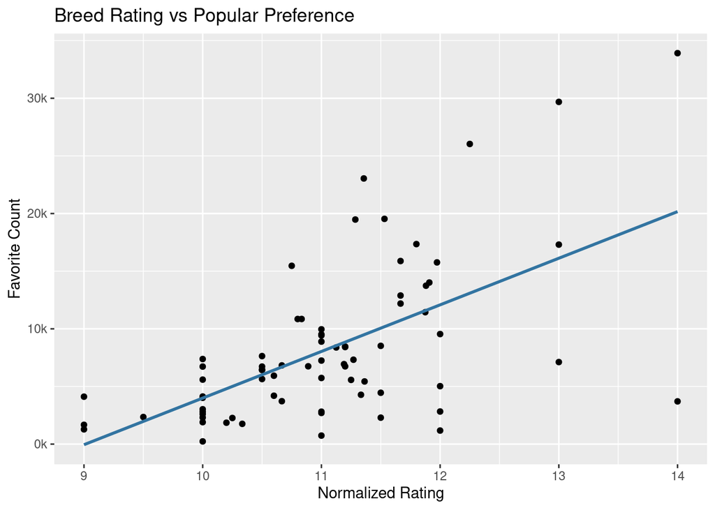

```r
ggplot(by_breed_mean, aes(x = mean_normalized_rating, y = mean_favorite_count)) +
  geom_point() +
  geom_smooth(method = "lm", se = FALSE, color = "#3274A1") +
  labs(
    x = "Normalized Rating",
    y = "Favorite Count",
    title = "Breed Rating vs Popular Preference"
  ) +
  scale_y_continuous(labels = comma_format(scale = 1e-3, suffix = "k"))
```

```r
r <- cor(by_breed_mean$mean_normalized_rating, by_breed_mean$mean_favorite_count)
R2 <- r^2

cat("      Correlation coefficient (r):    ", r, "\n")
```

```
##       Correlation coefficient (r):     0.5983534
```

```r
cat("Coefficient of determination (R2):    ", R2)
```

```
## Coefficient of determination (R2):     0.3580268
```

### Insights Recap:

1. The `rating_denominator` is $10 \times n$, where $n$ is the number of dogs.

   1.1. Normalized and stripped of outliers, the mean rating is 10.9 out of 10.
2. The neural network is not very confident in its dog breed predictions.
3. Being a unique breed appears to give a ratings boost.
4. The ratings correlate quite well with popular preference, though they are not very predictive.*

*This is normal for explanatory variables where the response variable is human behavior.